# Telemetria Maracanãs CEMAVE - ICMBio

Carlos Candia-Gallardo (USP)

25 de setembro de 2017

### Introdução

Roteiro para obter estimativas de localização de maracanãs (CEMAVE - ICMBio, Curaçá, BA) por triangulação (rádio-telemetria). Os dados (em formato .csv) podem ser baixados **aqui**. O arquivo com o código em R para rodar essa análise pode ser baixado **aqui**. Com estes arquivos é possível reproduzir a análise no R.

Antecipo os resultados obtidos na análise exportados em formato kml:

**Pontos de medição** (onde os coletores de dados obtiveram cada azimuth).

**Estimativas de localização** das maracanãs obtidas por triangulação.

Efetuando as análises percebi que as coordenadas de dois pontos de medição parecem estar incorretas, visto que eles ficaram bem deslocados dos demais (ver abaixo). **Neste arquivo** estão destacadas em amarelo essas coordenadas para vocês conferirem.

### Roteiro da análises

A seguir apresento os passos da análise comentados.

Carregando os pacotes necessários (é necessário instalá-los no R caso você não os tenha instalados):

```r
library(sigloc) #carregando o pacote sigloc que faz triangulações
library(rgdal) #carregando pacote para trabalhar com dados espaciais
library(maptools) #carregando pacote para trabalhar com dados espaciais e mapas
```

Importando os dados:

```r
data <- read.csv("dados.csv", sep = ";", dec = ",") # Importando os dados
```

Convertendo coordenadas dos pontos de medição de lat long para UTM. Isso é necessário pra fazer as triangulações com o pacote “sigloc”.

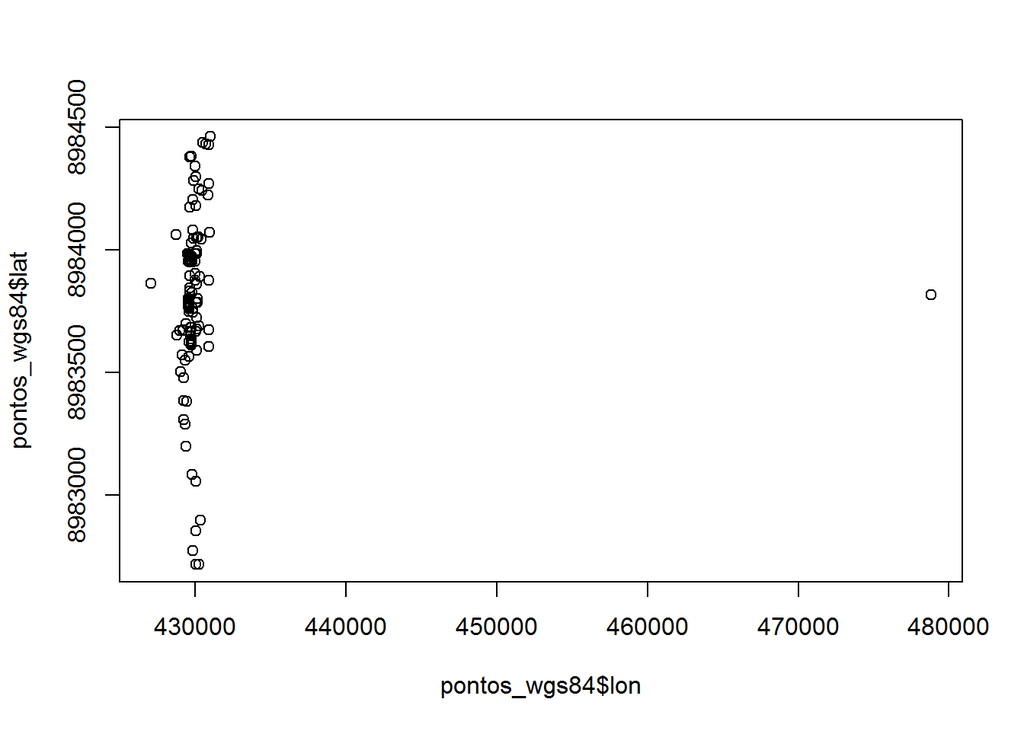

```r
pontos <- data[,c(3,5:6)] #extrai uma tabela apenas com as colunas de grupo (GID) e de coordenadas
    coordinates(pontos)<- c("lon", "lat") #converte as coordenadas em classe SpatialPoints
    BNG<- CRS("+init=epsg:27700 +proj=longlat +ellps=WGS84 +datum=WGS84 +south") #criando a projeção, datum, etc
    proj4string(pontos)<-BNG #inserindo projeção
    #criando projeção utm
    p4s <- CRS("+init=epsg:27700 +proj=utm +zone=24L +ellps=WGS84 +datum=WGS84 +south")
    pontos_wgs84 <- spTransform(pontos, CRS= p4s) #transformando as coordenadas em utm
    plot(pontos_wgs84$lon, pontos_wgs84$lat) #plotando os pontos de onde os azimuths foram obtidos
```

Na figura acima estão representados os pontos de medição onde foram obtidos os azimuths. É possível ver um ponto de medição bem deslocado à direita. Provavelmente é um erro de digitação.

Exportando kml (em formato lat/long) com os pontos de medição. Para baixar o kml diretamente clique **aqui**.

```r
 writeOGR(pontos, dsn="pontos_medicao.kml", layer= "pontos", driver="KML", dataset_options=c("NameField=name"))
```

Criando a tabela com os dados para as triangulações:

```r
        df <- data.frame(
          Date = data[,1],
          Observers = data[,2],
          GID = data[,3],
          Time = data[,4],
          Easting = as.data.frame(pontos_wgs84)[,2],
          Northing = as.data.frame(pontos_wgs84)[,3],
          Azimuth = data[,7]
        )
```

Agora é preciso corrigir a declinação magnética, i.e., a diferença entre o norte geográfico e norte magnético. Descobri que a declinação de Curaçá (Aracaju) é de 23°2’W. Consultei https://www.ngdc.noaa.gov/geomag-web/.

```r
library(measurements) #pacote para converter graus minutos decimais em graus decimais

    declin <- "23°2" ## declinação magnéctica de Curaçá (Aracaju)
    declin = gsub('°', ' ', declin) #substituindo o símbolo "°" por espaço " "
    declin = as.integer(conv_unit(declin, from = 'deg_dec_min', to = 'dec_deg'))
    #somando a declinação aos azimuths medidos na bússola
    data[,7] <- as.integer(round(df[,7] + declin))

    #subtraindo 360 de todos os azimutes que ficaram acima de 360
    for(i in 1:nrow(df)) {
      if(df$Azimuth[i] > 360){
        df$Azimuth[i] = as.integer(df$Azimuth[i] - 360)
      }
    }
```

Fazendo as triangulações:

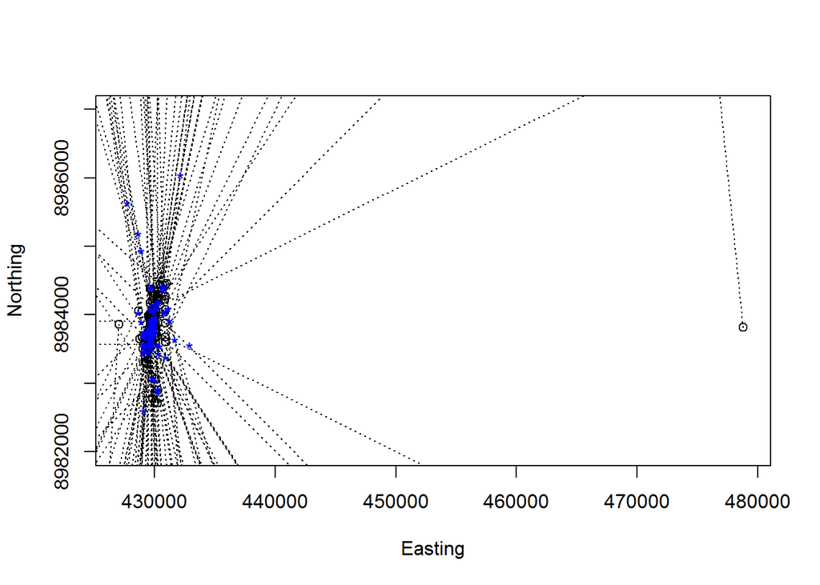

```r
 meds <- as.receiver(df)
  plot(meds,bearings=T,xlab="Easting",ylab="Northing",ylim = c(8982000,8987000), xlim = c(427200,479000))
  int <- findintersects(meds)
  plot(int, add = T, col = "blue")
```

Na figura acima os círculos vazados são os pontos de medição, as retas são os azimuths e os asteriscos azuis são as intersecções dos azimuths de uma mesma triangulação.

Agora vamos obter as localizações estimadas em cada triangulação com a função ‘locate’ do pacote ‘sigloc’.

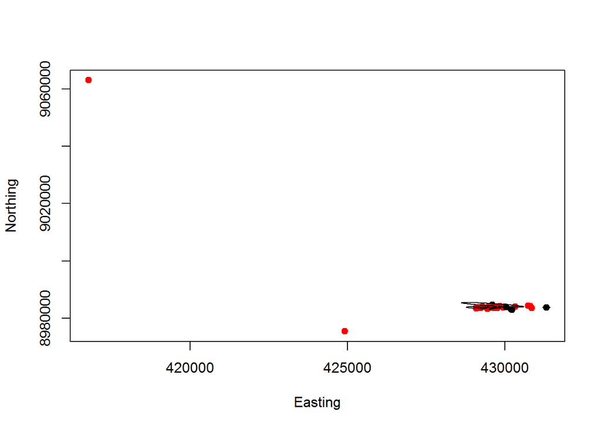

```r
  loc<-locate(meds)
  ## Display results with a different color for bad points
  plot(loc,badcolor=TRUE, errors = TRUE, xlab="Easting",ylab="Northing",add=F,col=c("blue","red"))
```

Na figura estão representadas as estimativas de localização obtidas por triangulação. Em vermelho estão representados os pontos onde um ou mais azimuths de suas respectivas triangulações destoam dos demais (bad points). Em preto estão os pontos bem triangulados. No entorno destes últimos está representada a elipse de confiança da estimativa (ruim de ver nessa escala, veja figura abaixo). Na figura acima há duas estimativas de localização bem deslocadas à esquerda que devem ser oriundas dos pontos de medição deslocados.

Vamos produzir o mesmo gráfico porém eliminando da visualização a localização outlier mais à esquerda pra facilitar a visualização das estimativas de posição bem calculadas.

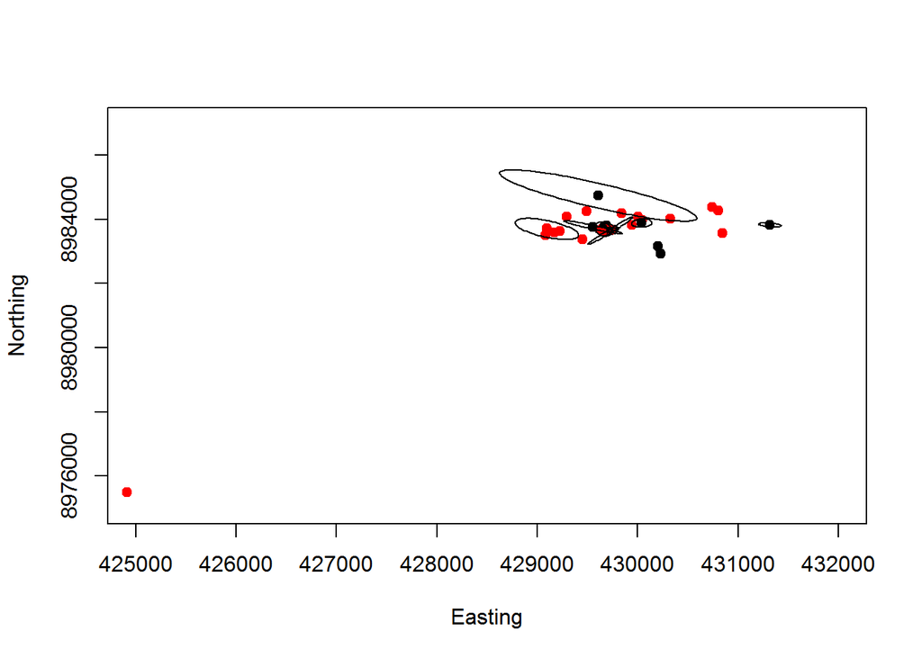

```r
#mesmo plot cortando o ponto outlier. Editei os limites do eixo x e y.
  plot(loc,badcolor=TRUE,errors = TRUE, add=F,col=c("blue","red"), xlim = c(425000,432000),ylim = c(8975000,8987000), xlab = "Easting", ylab = "Northing")
```

No gráfico acima as elipses de confiança representam o intervalo de 95% de precisão (estimador de máxima verossimilhança) das estimativas de localização. Apenas as estimativas oriundas de triangulações bem sucedidas (pontos pretos) possuem elipse de confiança. Para melhor visualizar as posições abra as estimativas de localização em kml no Google Earth.

Preparando para exportar as estimativas de localização.

```r
  posicoes <- data.frame(loc) #transformando as estimativas de localização em data frame
  posicoes <- posicoes[-which(is.na(posicoes)),] #eliminando NA (posições que não puderam ser estimadas)
  coordinates(posicoes)<- c("X", "Y") #transformando coordenadas em SpatialPoints
  BNG<- CRS("+init=epsg:27700 +proj=utm +zone=24L +ellps=WGS84 +datum=WGS84 +south")#ajustando projeção
  proj4string(posicoes)<-BNG
  p4s <- CRS("+init=epsg:27700 +proj=longlat +ellps=WGS84 +datum=WGS84") #convertendo em lat long
  posicoes<- spTransform(posicoes, CRS= p4s)
```

Exportando as posições estimadas em kml. Clique **aqui** para baixar o kml com as posições estimadas.

```r
      writeOGR(posicoes, dsn="estimativas_posicao_maracanas.kml", layer= "estimativas", driver="KML", dataset_options=c("NameField=name"))
```